# Homework10

Kendra Hodges

10/31/2018

### 1. Using a for loop, write function to calculate the number of zeroes ina numeric vector. Before entering the loop, set up a counter variable counter<- 0. inside the loop, add 1 to counter each time youhave a zero in the matric. Finall,y use return(counter) for the output.

```r
myVec <- sample(-5:5, size = 10, replace = TRUE)

countZeros <- function(myVec2=myVec) {
  counter <- 0
  for(i in seq_along(myVec2)){
    if(myVec2[i]==0) counter <- (counter+1)}

    return(counter)
}

countZeros()
```

```
## [1] 0
```

### 2. Use subsetting instead of a loop to rewrite the function as a single line of code.

```r
length(which(myVec ==0))
```

```
## [1] 0
```

### 3.Write a function that takes as input two integers representing the number of rows and columns in a matrix. The output is a matrix of these dimensions in which each element is the product of the row number x the column number.

```r
myMatrix <- function(x=5,y=6) {
  mat1 <- matrix(nrow=x, ncol=y)
  for(i in 1:nrow(mat1)){
    for(j in 1:ncol(mat1)){
      mat1[i,j] <- i*j
    }
  }
  return(mat1)
}

myMatrix()
```

```
##      [,1] [,2] [,3] [,4] [,5] [,6]
## [1,]    1    2    3    4    5    6
## [2,]    2    4    6    8   10   12
## [3,]    3    6    9   12   15   18
## [4,]    4    8   12   16   20   24
## [5,]    5   10   15   20   25   30
```

### 4. Use the code from yesterday’s class to design and conduct a randomization test for some of your own data. You will need to modify the functions that read in the data, calculate the metric, and randomize the data. Once those are set up, the program should run correctly calling your new functions. Also, to make your analysis fully repeatable, make sure you set the random number seed at the beginning (use either set.seed() in base R, or char2seed in the TeachingDemos package

```r
# Simulating of randomization test for regression
# October 30, 2018
# KLH
set.seed(100)
library(ggplot2)
library(TeachingDemos)
#char2seed("Autumn Leaves")

####
#function: readData

readData <- function(fileName=NULL){
  if(is.null(fileName)) {
    df <- data.frame(ID=10:24,
                     x=runif(15),
                     y=runif(15))
  } else {
    df <- read.table(file=fileName,
                     header=TRUE,
                     sep=",",
                     stringsAsFactors=FALSE)
  }

  return(df)
}
readData()
```

```
##    ID          x         y
## 1  10 0.30776611 0.6690217
## 2  11 0.25767250 0.2046122
## 3  12 0.55232243 0.3575249
## 4  13 0.05638315 0.3594751
## 5  14 0.46854928 0.6902905
## 6  15 0.48377074 0.5358112
## 7  16 0.81240262 0.7108038
## 8  17 0.37032054 0.5383487
## 9  18 0.54655860 0.7489722
## 10 19 0.17026205 0.4201015
## 11 20 0.62499648 0.1714202
## 12 21 0.88216552 0.7703016
## 13 22 0.28035384 0.8819536
## 14 23 0.39848790 0.5490967
## 15 24 0.76255108 0.2777238
```

```r
# Calculate the metric
getMetric <- function(z=NULL){
  if(is.null(z)){
    xObs <- 1:15
    yObs <- xObs + 10*rnorm(15)
    z <- data.frame(ID=seq_along(xObs),xObs,yObs)}
  . <- lm(z[,3]~z[,2])
  . <- summary(.)
  . <- .$coefficients[2,1]
  slope <- .
  return(slope)
}
getMetric()
```

```
## [1] 0.5609583
```

```r
# create randomization
shuffleData <- function(z=NULL){
  if(is.null(z)){
    xObs <- 1:15
    yObs <- xObs + 10*rnorm(15)
    z <- data.frame(ID=seq_along(xObs),xObs,yObs)}
  z[,3] <- sample(z[,3])
  return(z)
}
shuffleData()
```

```
##    ID xObs        yObs
## 1   1    1 20.22867391
## 2   2    2  1.62070388
## 3   3    3 -1.90014321
## 4   4    4  3.78205770
## 5   5    5 19.70202017
## 6   6    6  2.88806505
## 7   7    7 -4.76775632
## 8   8    8 19.57375622
## 9   9    9  0.08886439
## 10 10   10 19.65402327
## 11 11   11 12.17323286
## 12 12   12 26.03203489
## 13 13   13  8.82907684
## 14 14   14  9.77716649
## 15 15   15  9.98370762
```

```r
# calculate p value from simulated metrics
getPVAL <- function(z=NULL){
  if(is.null(z)){
    z <- list(xObs=runif(1),xSim=runif(100))}
  pLower <- mean(z[[2]]<=z[[1]])
  pUpper <- mean(z[[2]]>=z[[1]])
  return(c(pLower,pUpper))
}

getPVAL()
```

```
## [1] 0.63 0.37
```

```r
# create histogram of simulated and observed metric

# now use funtions to do the work!

plotRanTest <- function(z=NULL) {
  if(is.null(z)){
    z <- list(rnorm(1),rnorm(100)) }
  dF <- data.frame(ID=seq_along(z[[2]]),simX=z[[2]])
  p1 <- ggplot(data=dF,mapping=aes(x=simX))
  p1 + geom_histogram(mapping=aes(fill=I("goldenrod"),color=I("black"))) +
    geom_vline(aes(xintercept=z[[1]],col="blue"))

}

### Now use functions to do the work!
nSim <- 100
xSim <- rep(NA,nSim)
dF <- readData()
xObs <- getMetric(dF)


for(i in seq_len(nSim)){
  xSim[i] <- getMetric(shuffleData(dF))
}

slopes <- list(xObs, xSim)

getPVAL(slopes)
```

```
## [1] 0.49 0.51
```

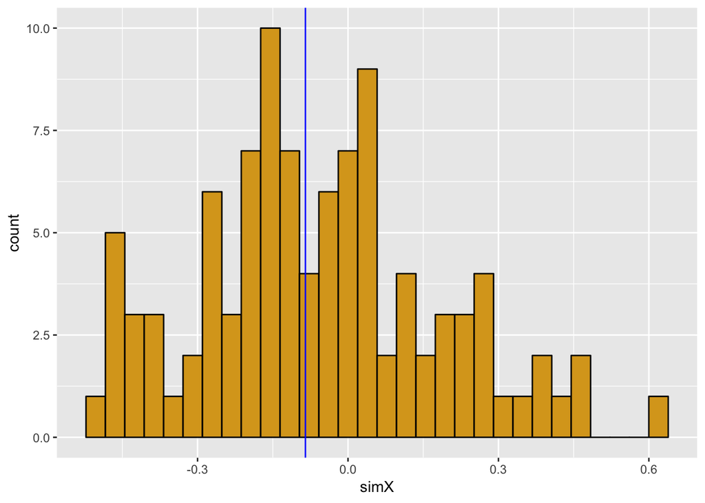

```r
plotRanTest(slopes)
```

```r
####

#load real data
myData <- read.csv("arthropod_data.csv", header = TRUE, stringsAsFactors = FALSE)


#pvalue with real data

myData <- read.csv("arthropod_data.csv")

getPVAL<- function(data=myData){
  if(is.null(myData)){
  myData <- list(xObs=runif(1),xSim=runif(1000))}
pLower <- mean(myData[[2]]<=myData[[1]])
pUpper <- mean(myData[[2]]>=myData[[1]])
return(c(pLower,pUpper))

  }
getPVAL()
```

```
## [1] 0.4509804 0.8627451
```